# Exercises H

Gerko Vink

Data Science and Predictive Machine Learning

# Introduction

In this practical, we will continue with regularized regression. We need the following packages:

```r
library(magrittr)
library(dplyr)
library(GGally)
library(glmnet)
library(caret)
library(plotmo)
library(coefplot)
```

We continue with the previous practical. For convenience, I have prepared an image with all necessary objects and functions from the previous practical so that we continue where we left off.

To load that workspace image, run the below code block.

```r
con <- url("https://www.gerkovink.com/erasmus/Day%203/Part%20H/load_all_objects.RData")
load(con)
```

The comparison in the previous practical was between OLS and Ridge regression for the `mtc` data. The `mtc` data set is our recoded version of the `mtcars` data, where the binary columns are set to factors. We created a training set (`train`) and a test set (`test`) based on this `mtc` data. If you recall, OLS performed worse than ridge regression

```r
postResample(pred, test$hp) # lm()
```

```
##       RMSE   Rsquared        MAE
## 36.5474077  0.7369976 32.7630202
```

```r
postResample(ridge_min, test$hp) # ridge with \lambda_min
```

```
##       RMSE   Rsquared        MAE
## 26.6839013  0.8118065 25.2053081
```

```r
postResample(ridge_1se, test$hp) # ridge with \lambda_1se
```

```
##      RMSE  Rsquared       MAE
## 29.517895  0.853422 23.769065
```

Before starting with the exercises, it is a good idea to set your RNG seed, so that (1) your answers are reproducible and (2) you can compare your answers with the answers provided.

```r
set.seed(123)
```

1. **Fit a lasso on the training data. Name the object `fit.lasso`. Do not do crossvalidation, yet.**

```r
fit.lasso <- glmnet(x = x, y = y,
                    family = "gaussian",
                    alpha = 1)
```

There is no need to set the argument `standardize = TRUE` to ensure that the predictors are *measured* in the same units, because it is by default set as `TRUE`.

2. **Inspect the plots on the fitted object. Use different x-axes.**

The first, generic plot on the `fit.lasso` object yields the plot of the coefficients against the $L_1$ norm.

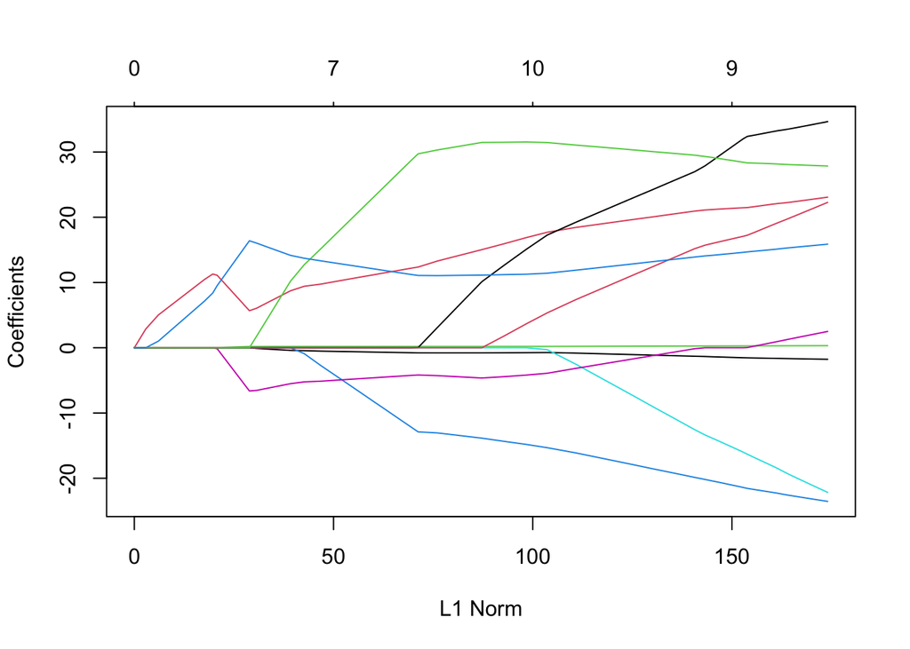

```r
plot(fit.lasso)
```

We can see that the harder the penalization, the more the coefficients are shrunk towards zero and the fewer non-zero coefficients remain. When the manhattan norm would result in zero, all coefficients are set to zero. The lasso clearly bets on sparsity.

Let’s look at the same plot, but now with $\text{Log}(\lambda)$ on the x-axis.

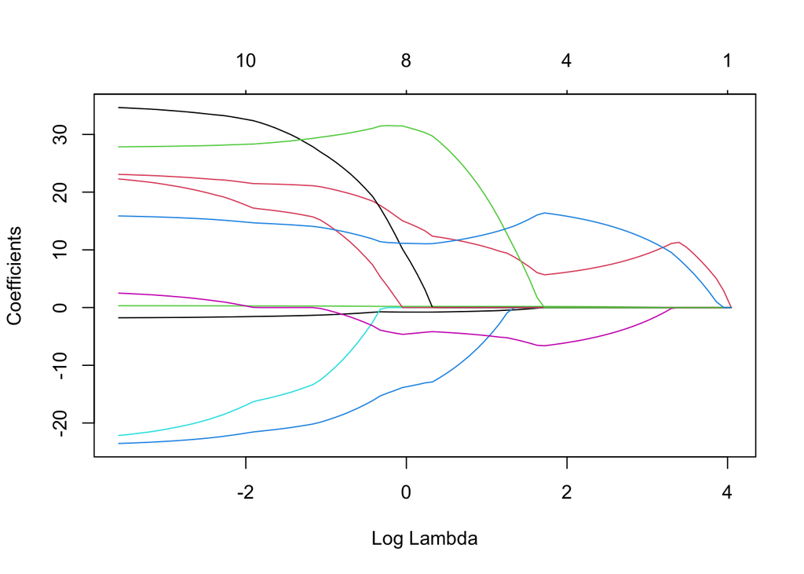

```r
plot(fit.lasso, xvar = "lambda")
```

It is clear that with increasing $\lambda$ comes increasing shrinkage and selection.

The final plot demonstrates the same trend, but now with the deviance on the x-axis.

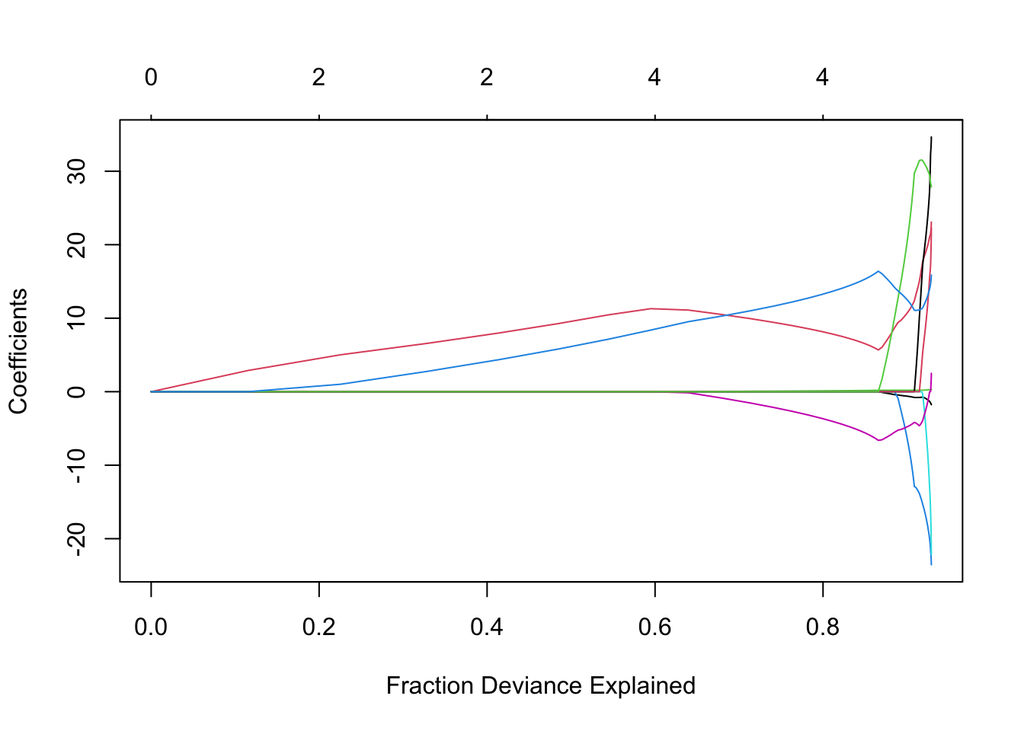

```r
plot(fit.lasso, xvar = "dev")
```

The function `plot_glmnet()` from package `plotmo` has a nicer - but very similar - plot class. I often prefer these plots over the native `plot.glmnet()`

3. **Recreate the plots from (2) with `plot_glmnet()`.**

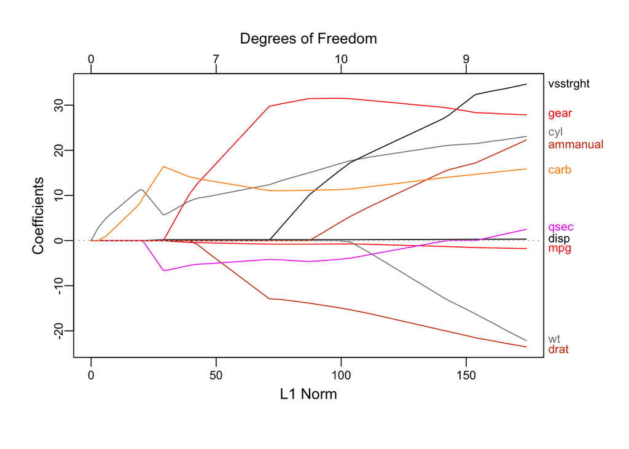

```r
plot_glmnet(fit.lasso, xvar = "norm")
```

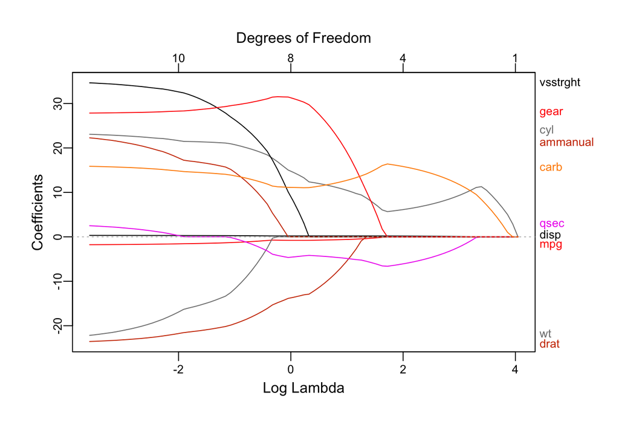

```r
plot_glmnet(fit.lasso, xvar = "lambda")
```

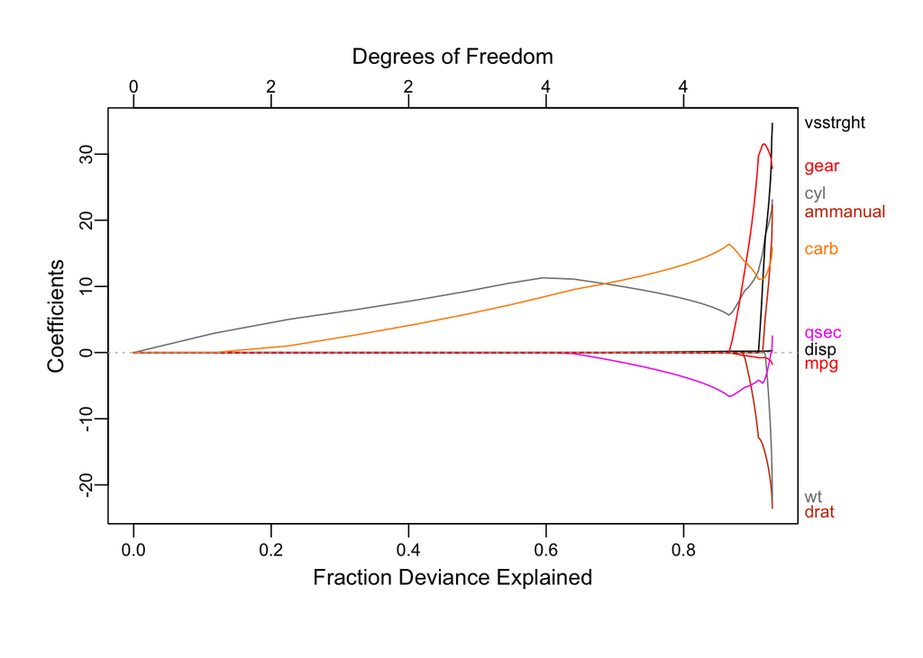

```r
plot_glmnet(fit.lasso, xvar = "dev")
```

And there is one extra plot in `plot_glmnet()` that reverses the $\text{Log}(\lambda)$ x-axis and gives the corresponding $\lambda$ values at the top margin. This is the plot that is returned by default by `plot_glmnet()` when the argument `xvar` is not specified.

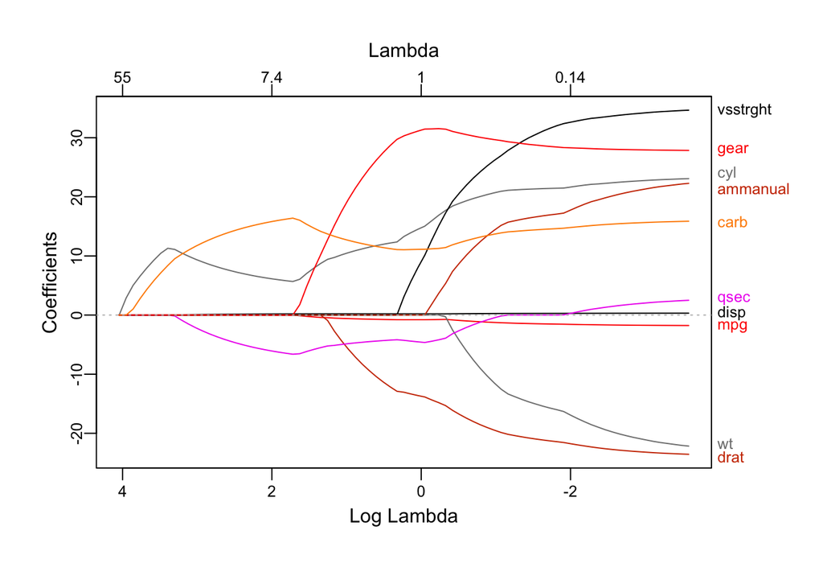

```r
plot_glmnet(fit.lasso)
```

4. **Train a lasso regression model on the `train` data set. Name the resulting object `lasso`. Use 4-fold crossvalidation, just like with ridge regression.**

To fit the lasso model, we need to specify `alpha = 1` in function `glmnet()`

```r
lasso <- cv.glmnet(x = x, y = y,
                   family = "gaussian",
                   alpha = 1,
                   standardize = TRUE,
                   nfolds = 4)
```

5. **Find out which value of $\lambda$ yields the lowest cross-validated error. Do a visual and a numeric inspection.**

Let’s first look at the plot.

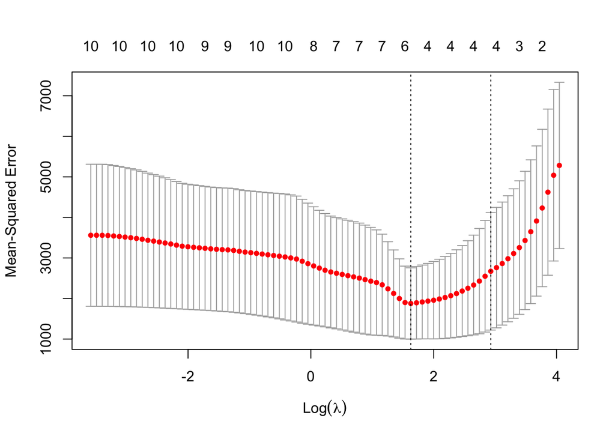

```r
plot(lasso)
```

It is clear that different values for $\text{Log}(\lambda)$ yield different Mean-squared Error (MSE). The optimum, that is the value of $\text{Log}(\lambda)$ for which the MSE is minimal lies at $\text{Log}(\lambda_{min}) =$ 1.6267717. The more parsimonious optimum that lies within 1 standard error can be found at $\text{Log}(\lambda_{1se}) =$ 2.9292441.

The `lasso` object also returns the optimal values for $\lambda$

```r
lasso
```

```
##
## Call:  cv.glmnet(x = x, y = y, nfolds = 4, family = "gaussian", alpha = 1,      standardize = TRUE)
##
## Measure: Mean-Squared Error
##
##     Lambda Index Measure     SE Nonzero
## min  5.087    27    1878  880.3       6
## 1se 18.713    13    2672 1449.5       4
```

Please note that these values are the $\lambda$ values and not the $\text{Log}(\lambda)$’s from the plot.

6. **Add the performance of the lasso regression to the comparison made earlier. Does the lasso perform better than ridge regression?**

Let’s take the more parsimonious $\lambda_{1se}$ as the $\lambda$-parameter for the Lasso regression.

```r
lasso_1se <- predict(lasso, s = "lambda.1se", newx = newx)
```

If we then compare the predicted values to the observations in the `test` object, we obtain the following performance measures.

```r
postResample(pred, test$hp) # lm
```

```
##       RMSE   Rsquared        MAE
## 36.5474077  0.7369976 32.7630202
```

```r
postResample(ridge_1se, test$hp) # ridge
```

```
##      RMSE  Rsquared       MAE
## 29.517895  0.853422 23.769065
```

```r
postResample(lasso_1se, test$hp) # lasso
```

```
##       RMSE   Rsquared        MAE
## 26.4962126  0.8682274 22.7184508
```

The lasso performs slightly better than ridge regression in this case. We must alsonote that the lasso does have fewer parameters to obtain nearly the same predictive performance:

```r
lasso %>% coef(s = "lambda.1se")
```

```
## 11 x 1 sparse Matrix of class "dgCMatrix"
##                      s1
## (Intercept) 84.27990432
## mpg          .
## cyl          8.98423993
## disp         0.08781704
## drat         .
## wt           .
## qsec        -2.67897374
## vsstraight   .
## ammanual     .
## gear         .
## carb        12.21460415
```

The lasso only uses 5 parameters, including the intercept. The ridge regression uses all 11 parameters. The lasso regression solution is therefor far more parsimonious.

```r
ridge %>% coef(s = "lambda.1se")
```

```
## 11 x 1 sparse Matrix of class "dgCMatrix"
##                       s1
## (Intercept) 186.48260848
## mpg          -1.06889609
## cyl           3.92218896
## disp          0.05429729
## drat         -5.16347160
## wt            4.55310965
## qsec         -4.14488672
## vsstraight  -11.27808604
## ammanual     -0.04598432
## gear          3.59664712
## carb          5.18327817
```

7. **Rerun the crossvalidated ridge regression again, but now only with the parameters selected by the lasso regression. Does performance increase?**

Let’s rerun the ridge regression, but first we need to adjust the model matrix.

```r
x.subset <- model.matrix(hp ~ -1 + cyl + disp + qsec + carb, data = train)
```

The `-1` in the formula excludes the `Intercept`. We don’t need the intercept in the design matrix because `glmnet()` will add it automatically.

Let’s fit the ridge model again

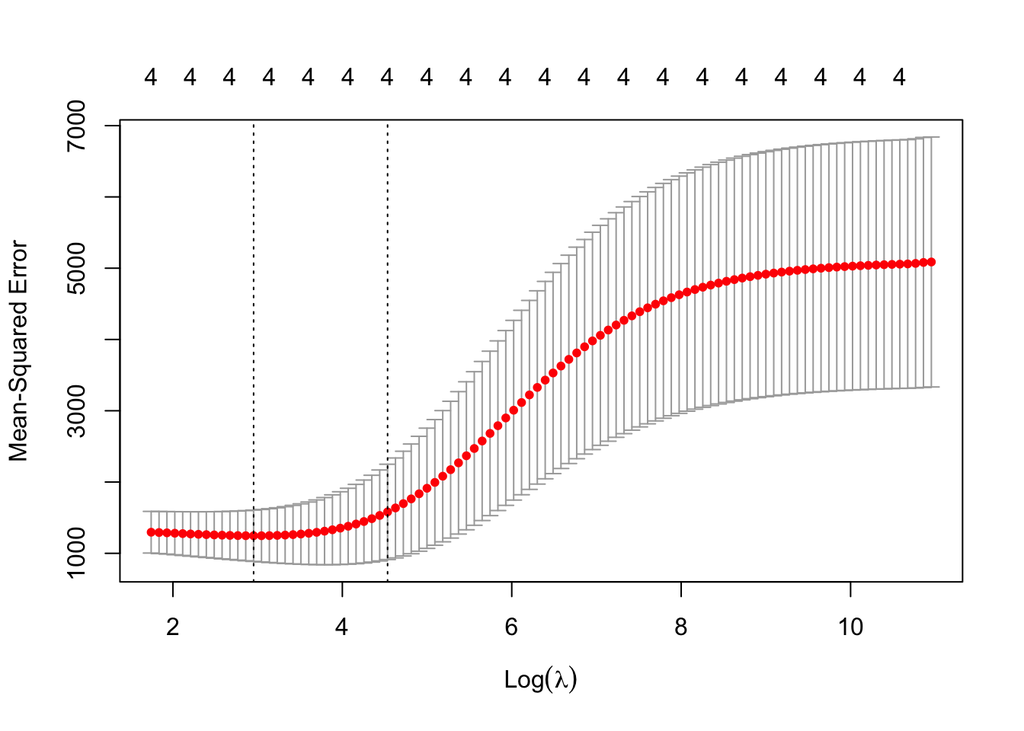

```r
ridge.subset <- cv.glmnet(x = x.subset, y = y,
                          family = "gaussian",
                          alpha = 0,
                          nfolds = 4)
plot(ridge.subset)
```

Now, let’s obtain the predicted values for the `ridge.subset` model.

```r
newx.subset <- model.matrix(hp ~ -1 + cyl + disp + qsec + carb, data = test)
ridge.subset_1se <- predict(ridge.subset, s = "lambda.1se", newx = newx.subset)
```

If we calculate the performance measures for the `ridge.subset` model

```r
postResample(ridge.subset_1se, test$hp)
```

```
##      RMSE  Rsquared       MAE
## 25.558627  0.877935 22.648077
```

we see that performance has indeed increased by making use of both $L_1$ and $L_2$ regularization.

# The elastic net

Instead of fitting the lasso and ridge regressions seperately, we can simultanous optimize the $L1$ and $L2$ norms. We then have to specify the ratio between these norms. That is done with `alpha` where $0\leq\alpha\leq1$ and an `alpha = 0` would mean ridge regression and an `alpha = 1` indicates the lasso.

8. **Fit an elastic net on the `train` data (not the subset) and set `alpha = 0.5`. Does performance on the `test` data increase?**

Let’s run the elastic net regression

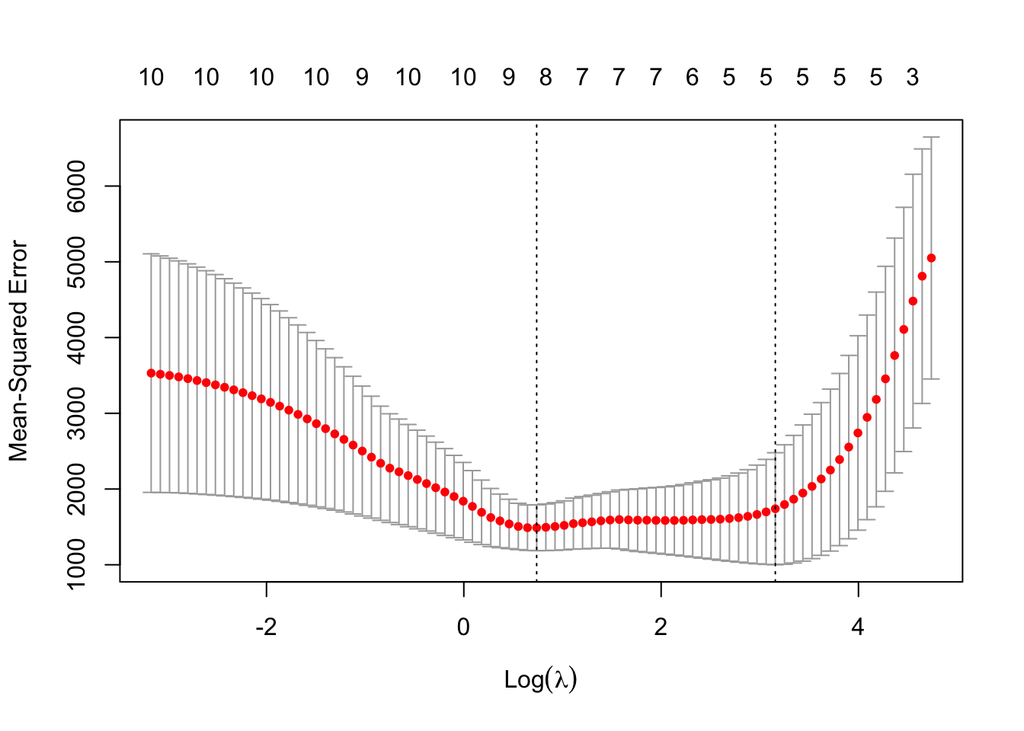

```r
e.net <- cv.glmnet(x = x, y = y,
                   family = "gaussian",
                   alpha = 0.5,
                   nfolds = 4)
plot(e.net)
```

The elastic net yields a slightly higher mean squared error than the previous `ridge.subset` solution.

```r
e.net
```

```
##
## Call:  cv.glmnet(x = x, y = y, nfolds = 4, family = "gaussian", alpha = 0.5)
##
## Measure: Mean-Squared Error
##
##     Lambda Index Measure    SE Nonzero
## min  2.092    44    1489 303.3       8
## 1se 23.505    18    1740 739.7       5
```

```r
ridge.subset
```

```
##
## Call:  cv.glmnet(x = x.subset, y = y, nfolds = 4, family = "gaussian",      alpha = 0)
##
## Measure: Mean-Squared Error
##
##     Lambda Index Measure    SE Nonzero
## min  19.15    87    1247 359.8       4
## 1se  93.14    70    1581 668.6       4
```

Let’s generate predicted values from the elastic net model

```r
e.net_1se <- predict(e.net, s = "lambda.1se", newx = newx)
```

If we calculate the performance measures for the `e.net` model

```r
postResample(e.net_1se, test$hp)
```

```
##       RMSE   Rsquared        MAE
## 23.0488087  0.8788349 20.5470349
```

we see that performance has slightly increased over our *hacky* $L_1$ and $L_2$ regularization.

**Different levels of `alpha`** will yield different performance. So, just like $\lambda$, $\alpha$ is a hyperparameter that can be optimized.

To do so, we need to define a tuning grid for the parameters `alpha` and `lambda`.

```r
grid <- expand.grid(alpha = seq(0.1, 1, by = .1),
                    lambda = seq(0.1, 30, by = .1))
grid %>% head(n=20)
```

```
##    alpha lambda
## 1    0.1    0.1
## 2    0.2    0.1
## 3    0.3    0.1
## 4    0.4    0.1
## 5    0.5    0.1
## 6    0.6    0.1
## 7    0.7    0.1
## 8    0.8    0.1
## 9    0.9    0.1
## 10   1.0    0.1
## 11   0.1    0.2
## 12   0.2    0.2
## 13   0.3    0.2
## 14   0.4    0.2
## 15   0.5    0.2
## 16   0.6    0.2
## 17   0.7    0.2
## 18   0.8    0.2
## 19   0.9    0.2
## 20   1.0    0.2
```

Now let’s fit the model (it may take a while!)

```r
model <- train(x, y,
               method = "glmnet",
               tuneGrid = grid,
               trControl = trainControl(method = "cv", number = 4))
```

The model has to navigate over the combinations specified in the tuning grid `grid`.

Let’s inspect the model

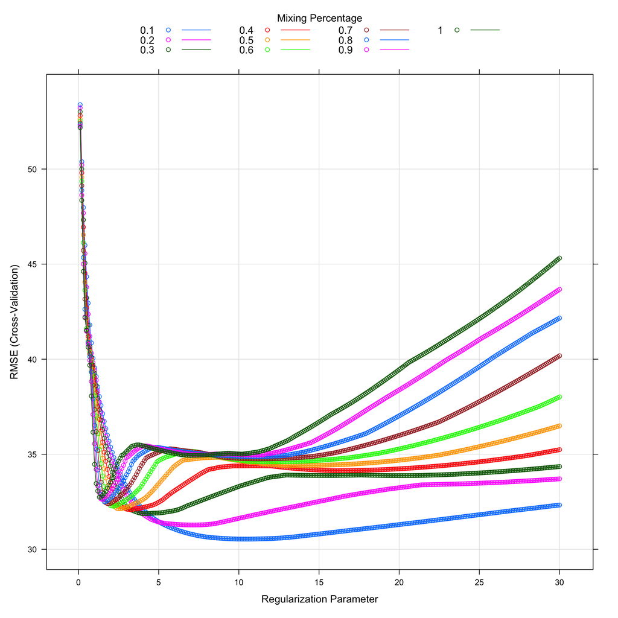

```r
plot(model)
```

The solution for the lambda’s is different from `glmnet`’s solution. This is because the cross-validated sampling is different. The `training` data is quite small, therefore the splitting can influence the hyperparameter optimization.

The *best* parameters that are obtained for `alpha` and `lambda` are

```r
model$bestTune
```

```
##     alpha lambda
## 105   0.1   10.5
```

Generating predicted values for the trained model:

```r
e.net.caret <- predict(model, newdata = newx)
```

The performance of the trained model is

```r
postResample(e.net.caret, test$hp)
```

```
##       RMSE   Rsquared        MAE
## 29.6317102  0.7849322 28.7840665
```

which is far worse than the performance of the `glmnet` elastic net with `alpha = 0.5`.

10. **Use the `alpha` and `lambda` obtained in the previous exercise to generate predictions with `glmnet`. Is the performance the same?**

```r
glmnet(x, y,
       alpha = model$bestTune$alpha,
       lambda = model$bestTune$lambda) %>%
  predict(newx = newx) %>%
  postResample(test$hp)
```

```
##       RMSE   Rsquared        MAE
## 29.6294425  0.7849857 28.7824998
```

The results are the same.

11. **Apply lasso regression to the prediction of `am` (automatic or manual cars) based on the following design matrix. Use the same train/test split**

```r
x <- model.matrix(am ~ -1 + mpg + disp + hp + drat + wt + qsec, data = train)
```

Let’s first generate the data parts to feed to `glmnet`.

```r
y <- train$am
x <- model.matrix(am ~ -1 + mpg + disp + hp + drat + wt + qsec, data = train)
```

Run the model

```r
fit <- cv.glmnet(x, y, family = "binomial", alpha = 1, nfolds = 4)
```

```
## Warning in lognet(xd, is.sparse, ix, jx, y, weights, offset, alpha, nobs, : one
## multinomial or binomial class has fewer than 8 observations; dangerous ground

## Warning in lognet(xd, is.sparse, ix, jx, y, weights, offset, alpha, nobs, : one
## multinomial or binomial class has fewer than 8 observations; dangerous ground
```

A lot of warnings are printed. There are few observations and the crossvalidation may bring us in dangerous territories. What if a fold contains only one class for the response?

12. **Inspect the lambda trace with `plot()`. What are the optimum values for `lambda`?**

Let’s inspect the model, despite the warnings earlier

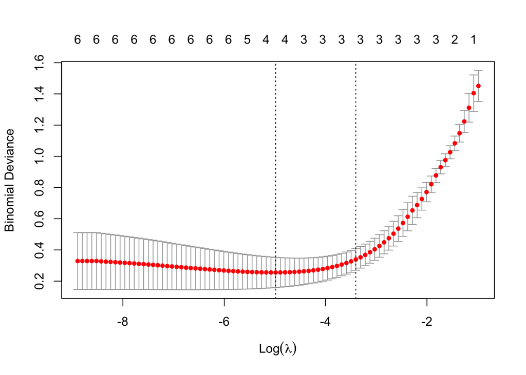

```r
plot(fit)
```

The deviance stays relatively constant at the beginning, but increases steeply when $\lambda$ becomes larger.

The optimal values for $\lambda$ are

```r
fit
```

```
##
## Call:  cv.glmnet(x = x, y = y, nfolds = 4, family = "binomial", alpha = 1)
##
## Measure: Binomial Deviance
##
##      Lambda Index Measure      SE Nonzero
## min 0.00684    44  0.2554 0.09672       4
## 1se 0.03324    27  0.3390 0.06950       3
```

13. **Can you reasonably predict the values of `am` with this model?**

```r
newx <- model.matrix(am ~ -1 + mpg + disp + hp + drat + wt + qsec, data = test)
pred <- fit %>%
  predict(newx = newx, type = "class")
postResample(pred, test$am)
```

```
## Accuracy    Kappa
##    0.875    0.750
```

Yes; only one mistake. Not bad!

14. **Inspect the confusion matrix? Is the performance still good?**

```r
newx <- model.matrix(am ~ -1 + mpg + disp + hp + drat + wt + qsec, data = test)
pred <- fit %>%
  predict(newx = newx, type = "class")
confusionMatrix(factor(pred), test$am)
```

```
## Confusion Matrix and Statistics
##
##            Reference
## Prediction  automatic manual
##   automatic         4      0
##   manual            1      3
##
##                Accuracy : 0.875
##                  95% CI : (0.4735, 0.9968)
##     No Information Rate : 0.625
##     P-Value [Acc > NIR] : 0.135
##
##                   Kappa : 0.75
##
##  Mcnemar's Test P-Value : 1.000
##
##             Sensitivity : 0.800
##             Specificity : 1.000
##          Pos Pred Value : 1.000
##          Neg Pred Value : 0.750
##              Prevalence : 0.625
##          Detection Rate : 0.500
##    Detection Prevalence : 0.500
##       Balanced Accuracy : 0.900
##
##        'Positive' Class : automatic
##
```

Performance is much better than the baseline performance.

15. **How would a logistic model have performed?**

```r
pred <- glm(am ~ mpg + disp + hp + drat + wt + qsec, data = train,
            family = binomial(link = "logit")) %>%
  predict(newdata = test,
          type = "response")
confusionMatrix(factor(ifelse(pred > .5, "manual", "automatic")),
                test$am)
```

```
## Confusion Matrix and Statistics
##
##            Reference
## Prediction  automatic manual
##   automatic         4      0
##   manual            1      3
##
##                Accuracy : 0.875
##                  95% CI : (0.4735, 0.9968)
##     No Information Rate : 0.625
##     P-Value [Acc > NIR] : 0.135
##
##                   Kappa : 0.75
##
##  Mcnemar's Test P-Value : 1.000
##
##             Sensitivity : 0.800
##             Specificity : 1.000
##          Pos Pred Value : 1.000
##          Neg Pred Value : 0.750
##              Prevalence : 0.625
##          Detection Rate : 0.500
##    Detection Prevalence : 0.500
##       Balanced Accuracy : 0.900
##
##        'Positive' Class : automatic
##
```

# Final challenge for today

# Gene expression data

The data file we will be working with is the [gene expression data](https://www.ebi.ac.uk/arrayexpress/experiments/E-MTAB-6694). Using microarrays, the expression of many genes can be measured at the same time. The data file contains expressions for 54675 genes with IDs such as `1007_s_at`, `202896_s_at`, `AFFX-r2-P1-cre-3_at`. (NB: these IDs are specific for this type of chip and need to be converted to actual gene names before they can be looked up in a database such as “GeneCards”). The values in the data file are related to the amount of RNA belonging to each gene found in the tissue sample.

The goal of the study for which this data was collected is one of exploratory cancer classification: are there differences in gene expression between tissue samples of human prostates with and without prostate cancer?

**CHALLENGE: Use the `challenge.zip` archive on the course website to predict `Disease` from a huge set of genotypes as accurately as possible using either ridge regression, lasso regression or a combination thereof (elastic net or hacky way).**

Rules:

- Code must be submitted to me at G.Vink@uu.nl - use the `challenge.Rmd` file from the challenge archive
- use `glmnet` or `caret`
- Fix your seed
- Use a 80/20 train/test split
- Train your model on the training set
- Performance is calculated on the test set
- Highest Accuracy with highest Kappa wins!
- Deadline is Wednesday 5pm

The best performing model will be awarded a prize next week (or per mail)

End of Practical